# Findings: Data viz outside psych sci – PSYCH 490.007

- Show All Code
- Hide All Code
- View Source

Published

October 28, 2026

## About

This page extracts information about the data visualizations we explored in Exercise-02 from the shared Google Sheet.

## Google Sheet

Direct link:

https://docs.google.com/spreadsheets/d/1bTMuWopvUz8M1OHQU5mnMvWXvBMb3tj2sLFLGXHzviI/edit?usp=sharing

## Preparation

First, we load the external packages (groups of R commands) that we will be using.

**Important**

The code uses the `quietly()` function from the `purrr` package to suppress most of the feedback.

```r
library('ggplot2')
library('dplyr')

r_functions <- list.files(file.path(here::here(), "R"), "\\.R$", full.names = TRUE)

purrr::map(r_functions, source) |>
  purrr::quietly()
```

```
function (...)
capture_output(.f(...))
<bytecode: 0x82938b2a0>
<environment: 0x82938afc8>
```

## Gathering

Next, we download the data from the Google Sheet where it is collected. Dr. Gilmore has stored his Google account credentials in a special environment file that can be accessed by the R command `Sys.getenv("GMAIL_SURVEY")`.

**Tip**

It’s vital to be *very* careful when creating and sharing code like this that involves sensitive information like login credentials.

```
GMAIL_SURVEY="<my-google-account>"
```

Here, he has substituted his Google account with credentials/access to the required files for `<my-google-account>`. Then, when the R code below calls `Sys.getenv("GMAIL_SURVEY")`, the value of those credentials is returned as a text string.

Make sure to close and save the `.Renviron` file and restart your R session before testing this yourself.

```r
if (!dir.exists('csv')) {
  message("Creating missing `csv/`.")
  dir.create("csv")
}

if (params$update_data) {
  options(gargle_oauth_email = Sys.getenv("GMAIL_SURVEY"))
  googledrive::drive_auth()

  googledrive::drive_download(
    "PSYCH-490.007-Fall-2026-Biz-Govt",
    path = file.path("csv", params$fn),
    type = "csv",
    overwrite = TRUE
  )
  message("Data updated.")
} else {
  message("Using stored data.")
}
```

The data file has been saved as a comma-separated value (CSV) format data file in a special directory called `csv/`.

**Note**

Because these data *might* contain sensitive or identifiable information, we only keep a local copy and do not share it publicly via GitHub. This is achieved by adding the name of the data directory to a special `.gitignore` file.

## Cleaning

Next we load the saved data file, and then proceed to clean it.

```r
ex02 <-
  readr::read_csv(file.path("csv", params$fn), show_col_types = FALSE)
```

There are 20 responses.

These are the column/variable names.

```r
# Google Forms puts the full question in the top row of the data file.
# We use the names() function to extract and print the original questions.
ex02_qs <- names(ex02)
ex02_qs
```

```
 [1] "identifier"      "source_type"     "url_to_src"      "bar_column"
 [5] "pie_ring"        "scatter"         "hist_box_violin" "other"
 [9] "url_to_figure"   "why_selected"    "comment"
```

For simplicity, we visualize below only those with non-empty URLs to the specific figure.

## Summary data

```r
figs_w_urls <- ex02 |>
  filter(!is.na(url_to_figure))
```

There were *n*=7 unique respondents.

Of the 20 responses from these individuals or teams, *n*=16 had URLs we could link to directly.

## Figures found

```r
these_figs <- ex02 |>
  filter(!is.na(url_to_figure))

res <- invisible(lapply(1:dim(these_figs)[1], return_img_chunk, df = these_figs))
cat(unlist(res), sep = "\n")
```

### Figure 1

**Source**: https://www.pewresearch.org/journalism/2026/07/16/how-americans-are-engaged-with-news-politics-religion-and-civic-life/

[figure not shown]

| Analyst | Source Type | Why Selected |
| --- | --- | --- |
| ganiya | report | NA |

| Comments |
| --- |
| NA |

### Figure 2

**Source**: https://www.nature.com/articles/s41598-025-86883-2?fromPaywallRec=false

[figure not shown]

| Analyst | Source Type | Why Selected |
| --- | --- | --- |
| ganiya | report | NA |

| Comments |
| --- |
| NA |

### Figure 3

**Source**: https://www.pewresearch.org/short-reads/2025/10/29/how-americans-trust-in-information-from-news-organizations-and-social-media-sites-has-changed-over-time/

[figure not shown]

| Analyst | Source Type | Why Selected |
| --- | --- | --- |
| ganiya | research | NA |

| Comments |
| --- |
| NA |

### Figure 4

**Source**: https://www.ibm.com/thought-leadership/institute-business-value/en-us/report/business-trends-2026

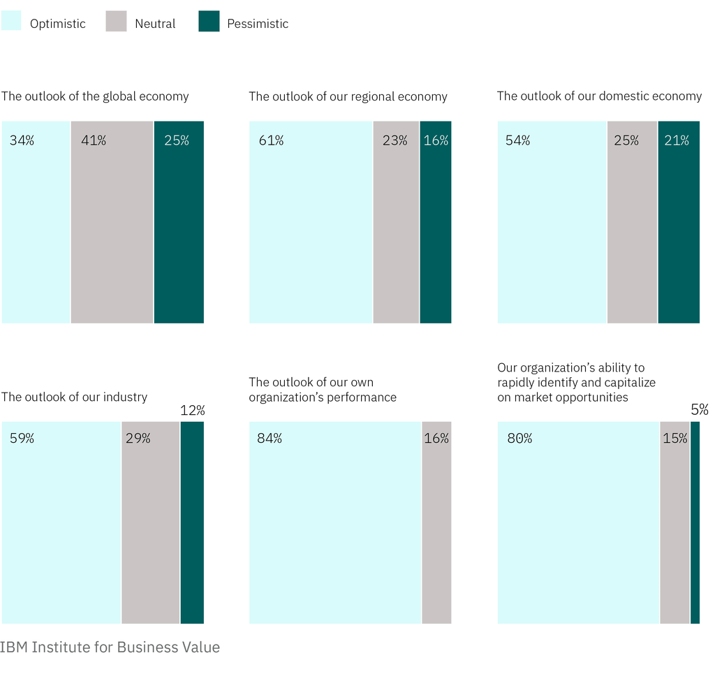

| Analyst | Source Type | Why Selected |
| --- | --- | --- |
| natalie | report | Interesting to see greater optimism for organizations compared to global/national economies |

| Comments |
| --- |
| Executive Perspectives |

### Figure 5

**Source**: https://www.pewresearch.org/global/2026/02/17/where-in-the-world-are-people-proud-of-their-countrys-culture-and-lifestyle/

[figure not shown]

| Analyst | Source Type | Why Selected |
| --- | --- | --- |
| natalie | report | Shows differences in national pride for arts/cultures around the world |

| Comments |
| --- |
| Bar graph descending by % |

### Figure 6

**Source**: https://www.pewresearch.org/short-reads/2024/02/05/by-a-wide-margin-americans-say-football-not-baseball-is-americas-sport/

[figure not shown]

| Analyst | Source Type | Why Selected |
| --- | --- | --- |
| natalie | report | Shows strong evidence that football is recognized as america’s sports even by those who don’t keep up with sports |

| Comments |
| --- |
| Bar graph descending by % |

### Figure 7

**Source**:

[figure not shown]

| Analyst | Source Type | Why Selected |
| --- | --- | --- |
| Daniel | NA | NA |

| Comments |
| --- |
| NA |

### Figure 8

**Source**: https://ourworldindata.org/data-insights/global-average-life-expectancy-has-more-than-doubled-since-1900

[figure not shown]

| Analyst | Source Type | Why Selected |
| --- | --- | --- |
| Paul | NA | NA |

| Comments |
| --- |
| NA |

### Figure 9

**Source**: https://viziball.app/nba/en/player/20260605/20260613/fc/1/10/avg/DESC/0/48/0/100/all/all

[figure not shown]

| Analyst | Source Type | Why Selected |
| --- | --- | --- |
| Paul | NA | NA |

| Comments |
| --- |
| NA |

### Figure 10

**Source**: https://www.statista.com/chart/32866/least-listened-to-genres/

[figure not shown]

| Analyst | Source Type | Why Selected |
| --- | --- | --- |
| Paul | NA | NA |

| Comments |
| --- |
| NA |

### Figure 11

**Source**: https://www.advancedfootballanalytics.com/2010/01/run-pass-balance-historical-analysis.html

[figure not shown]

| Analyst | Source Type | Why Selected |
| --- | --- | --- |
| Aiden/Luana | Research | Interesting to show sports frequency changes over time in american football |

| Comments |
| --- |
| Football, table |

### Figure 12

**Source**: https://www.oliverwyman.com/our-expertise/insights/2026/jan/impact-ai-bubble-burst-on-global-financial-markets.html

[figure not shown]

| Analyst | Source Type | Why Selected |
| --- | --- | --- |
| Aiden/Luana | Research | Interesting data that shows swings in the AI bubble market over time |

| Comments |
| --- |
| Economics, table |

### Figure 13

**Source**: https://www.economist.com/graphic-detail/2026/07/26/how-big-is-americas-obesity-penalty

[figure not shown]

| Analyst | Source Type | Why Selected |
| --- | --- | --- |
| Aiden/Luana | journalism | I selected this because I find the rise of GLP-s very intresting |

| Comments |
| --- |
| Line graph showing increase in rates of marriage, emplyment, and hours worked |

### Figure 14

**Source**: https://ourworldindata.org/a-never-ending-childhood-of-malaria

[figure not shown]

| Analyst | Source Type | Why Selected |
| --- | --- | --- |
| Ishita | Website | easy to see how frequently individual children experience malaria |

| Comments |
| --- |
| Bar graph showing malaria infections |

### Figure 15

**Source**: https://www.bea.gov/data/special-topics/arts-and-culture

[figure not shown]

| Analyst | Source Type | Why Selected |
| --- | --- | --- |
| Ishita | Website | easy to understand arts and cultural economic activity across states |

| Comments |
| --- |
| Government/BEA source; includes state-level data |

### Figure 16

**Source**: https://ourworldindata.org/grapher/population-with-un-projections?

[figure not shown]

| Analyst | Source Type | Why Selected |
| --- | --- | --- |
| Ishita | website | Shows population changes over time and includes projections for future population |

| Comments |
| --- |
| NA |